# Lecture 07

2026-04-21

## Activity 1 (Always Anonymous)

### QR Code (it’s getting better)

This is anonymous & optional, but helpful to Stats 20,

[figure not shown]

or here is a [direct link](https://www.menti.com/blgqmhyos5n1)

# Data Visualization Week

## Translating Data Visually

- Data contains relationships, our job is to make the relationships we see in the data accessible to others
- Involves learning to structure and organize our data for effective presentation
- Also we will learn about the different types of representation and their purpose
- Encourage you to work on presenting your visualizations in preparation for Project 2/3

## Keep in mind

- Who is your audience?
- Have an idea that you can share with them
- Find some data related to your idea (sometimes ideas come after the data is found)
- Prepare the data for analysis and visualization
- Represent the data using graphical elements
- (optionally/more advanced) Post-process the data - decide if adding interactivity would add power
- There is a story behind the data and the analysis, part of your job is to bring it out.

## This week’s outline

- Base R graphics, first
- then, Tidyverse and ggplot2

## Understanding R’s Graphic System

- R has a (1) traditional graphics system and also (2) a grid graphics system
- The most popular visualization package in R is `ggplot2` which is a graphics system that is an implementation of the grid graphics system. (next lecture)
- The traditional graphic system is automatically loaded at startup.
- If you issue a library(help=“graphics”) at the console, you will see all of the basic graphics options. But there is no way we can cover all of them, we’ll examine only the most common/most useful/things you were taught in previous statistics courses.

## Base R graphics functions

```
> library(help="graphics")

Axis                    Generic Function to Add an Axis to a Plot
abline                  Add Straight Lines to a Plot
arrows                  Add Arrows to a Plot
assocplot               Association Plots
axTicks                 Compute Axis Tickmark Locations
axis                    Add an Axis to a Plot
axis.POSIXct            Date and Date-time Plotting Functions
barplot                 Bar Plots
box                     Draw a Box around a Plot
boxplot                 Box Plots
boxplot.matrix          Draw a Boxplot for each Column (Row) of a
                        Matrix
bxp                     Draw Box Plots from Summaries
cdplot                  Conditional Density Plots
clip                    Set Clipping Region
contour                 Display Contours
coplot                  Conditioning Plots
curve                   Draw Function Plots
dotchart                Cleveland's Dot Plots
filled.contour          Level (Contour) Plots
fourfoldplot            Fourfold Plots
frame                   Create / Start a New Plot Frame
graphics-package        The R Graphics Package
grconvertX              Convert between Graphics Coordinate Systems
grid                    Add Grid to a Plot
hist                    Histograms
hist.POSIXt             Histogram of a Date or Date-Time Object
identify                Identify Points in a Scatter Plot
image                   Display a Color Image
layout                  Specifying Complex Plot Arrangements
legend                  Add Legends to Plots
lines                   Add Connected Line Segments to a Plot
locator                 Graphical Input
matplot                 Plot Columns of Matrices
mosaicplot              Mosaic Plots
mtext                   Write Text into the Margins of a Plot
pairs                   Scatterplot Matrices
panel.smooth            Simple Panel Plot
```

[output cut: 22 more lines]

```
smoothScatter           Scatterplots with Smoothed Densities Color
                        Representation
spineplot               Spine Plots and Spinograms
stars                   Star (Spider/Radar) Plots and Segment Diagrams
stem                    Stem-and-Leaf Plots
stripchart              1-D Scatter Plots
strwidth                Plotting Dimensions of Character Strings and
                        Math Expressions
sunflowerplot           Produce a Sunflower Scatter Plot
symbols                 Draw Symbols (Circles, Squares, Stars,
                        Thermometers, Boxplots)
text                    Add Text to a Plot
title                   Plot Annotation
xinch                   Graphical Units
xspline                 Draw an X-spline
```

## The Logic of Constructing Plots in R

- The functions on the previous slide could be roughly categorized in “high level” and “low level” functions.
- A plot is created in base R graphics by first calling a high-level function.
- A high-level graphics function can create a plot and does not require any other function to precede it
- A low-level graphics function are called to add more output to the plot (such as additional lines or points). These functions depend on a previous high-level function.
- Plots created in base R are layered like a cake. We initialize a plot with a high level function and then layer it with additional information provided by low level functions

## Rough Categorization

| Category | Purpose | Examples |
| --- | --- | --- |
| **High-Level** | Bottom Layer of the “cake” | `plot()`, `hist()`, `boxplot()`, `barplot()`, `heatmap()`, `pairs()`, `persp()`, `contour()`, `smoothScatter()` |
| **Low-Level** | Added “cake” layers | `points()`, `lines()`, `abline()`, `text()`, `legend()`, `axis()`, `title()`, `segments()`, `rug()` |

## plot()

- The most important high-level plotting function in base R graphics is plot( )
- plot can be used to create simple scatter plots( ) (among other things)
- plot( ) can take many arguments allowing for extreme customization.
- The first argument to plot( ) is data, usually a vector, but it could be a data frame. plot() will behave differently depending on the data
- The second argument can usually be anything…

## single numeric vector

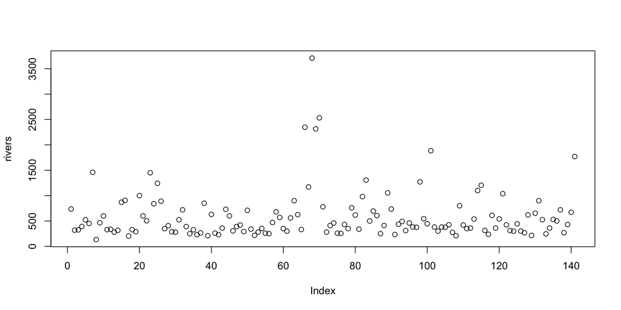

```r
plot(rivers)
```

## data frame with two numeric vectors

Here are two vectors in a data frame:

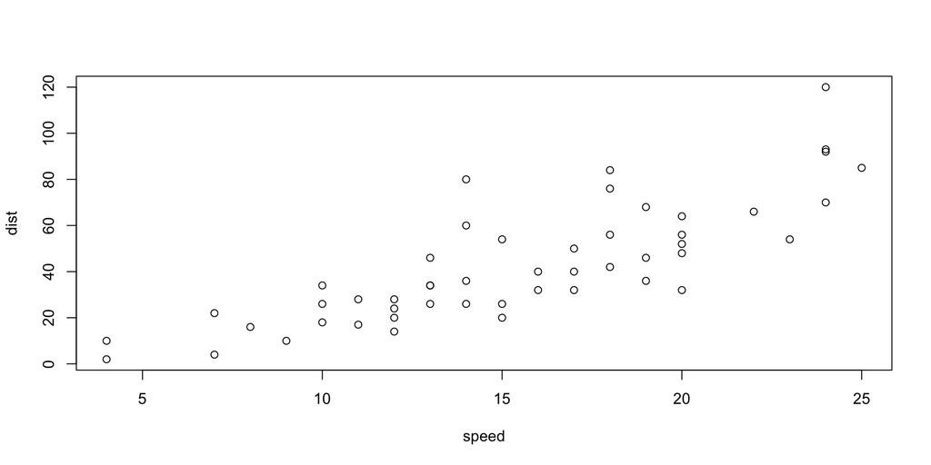

```r
plot(cars)
```

## a data frame with more than two

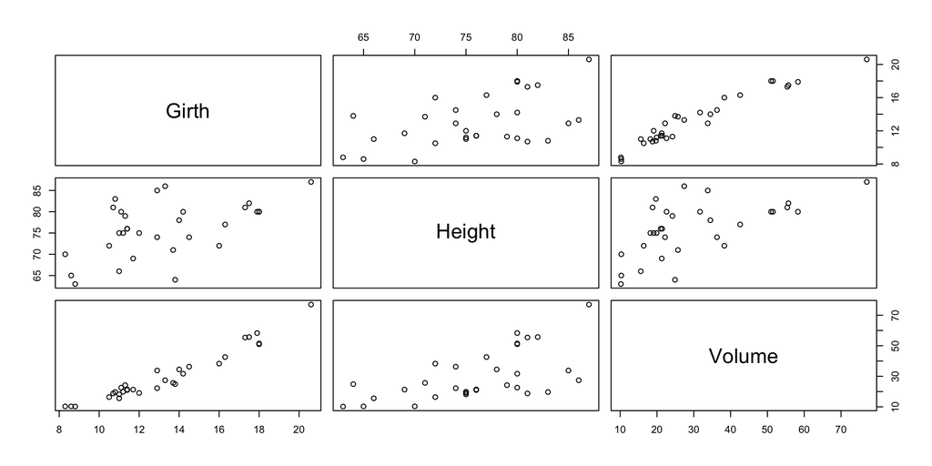

```r
plot(trees)
```

## two specific vectors from many

- You must specify them, x first, then y (unless you use argument names x= and y=). Extraction is an important skill. All 3 lines below will give exactly the same plot:

```r
op <- par()
par(mfrow = c(2, 2))

plot(iris$Sepal.Length, iris$Sepal.Width, main = "No argument names")
# works but bad for communication

plot(x = iris$Sepal.Length, y = iris$Sepal.Width, main = "Argument names")
# 102 happy place, named and in order

plot(y = iris$Sepal.Width, x = iris$Sepal.Length, main = "Argument names, any order")
# always clear when you use argument naming

par(op)
```

- You will see par() after the break, here I am copying the existing, then modifying a default from one plot per images to 2 by 2 or 4 images then restoring the original.

## Result

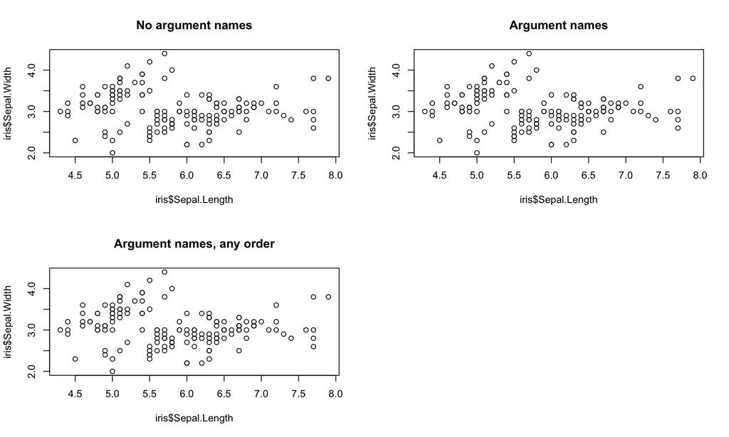

## Only two specific vectors, formula

- This is acceptable to most. Looks like 101ABC style modeling.
- plot() recognizes a formula and it accesses a special method plot.formula() to evaluate your specifications.

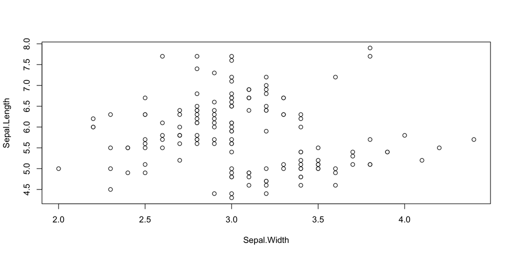

```r
plot(Sepal.Length ~ Sepal.Width, data = iris)
```

If instead, you wrote this, it will result in an error.

```r
plot(y = Sepal.Length, x = Sepal.Width, data = iris)  # result is an error
```

## (alt) only two vectors, formula

- This is acceptable if you are not going into 102ABC and don’t like the tilde.
- It is easy to understand and avoids explaining symbols to a non-technical audience

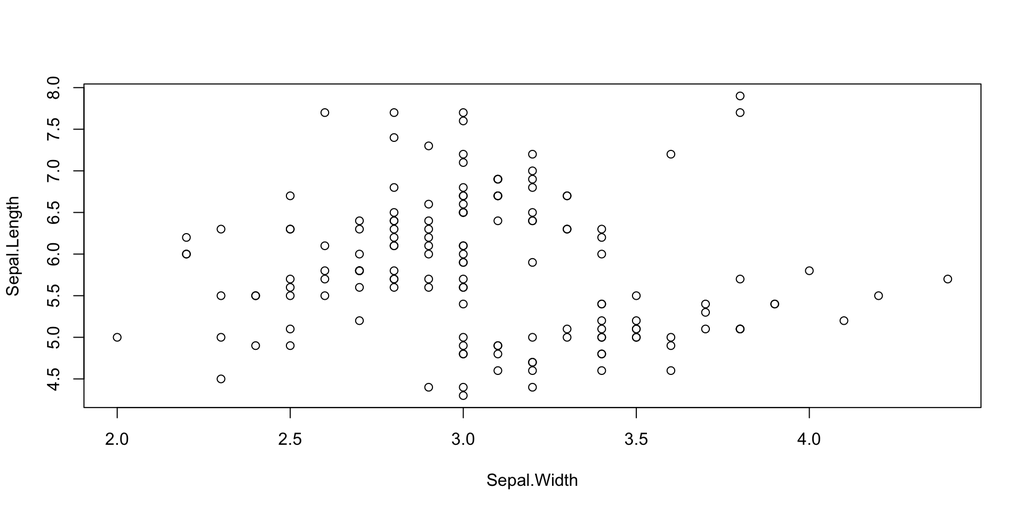

```r
with(iris, plot(Sepal.Width, Sepal.Length))
```

## plot() help - description and usage

```
help(plot)

The Default Scatterplot Function

Description:

     Draw a scatter plot with decorations such as axes and titles in
     the active graphics window.

Usage:

     ## Default S3 method:
     plot(x, y = NULL, type = "p",  xlim = NULL, ylim = NULL,
          log = "", main = NULL, sub = NULL, xlab = NULL, ylab = NULL,
          ann = par("ann"), axes = TRUE, frame.plot = axes,
          panel.first = NULL, panel.last = NULL, asp = NA,
          xgap.axis = NA, ygap.axis = NA,
          ...)
```

The `...` suggests even more potential options not fully documented. So if you include an argument that plot() does recognize, it passes it along to associated other functions. Problem is, R doesn’t necessarily tell you if it’s completely unrecognized, things just don’t happen.

## plot() help - arguments

```
Arguments:

    x, y: the ‘x’ and ‘y’ arguments provide the x and y coordinates for
          the plot.  Any reasonable way of defining the coordinates is
          acceptable.  See the function ‘xy.coords’ for details.  If
          supplied separately, they must be of the same length.

    type: 1-character string giving the type of plot desired.  The
          following values are possible, for details, see ‘plot’: ‘"p"’
          for points, ‘"l"’ for lines, ‘"b"’ for both points and lines,
          ‘"c"’ for empty points joined by lines, ‘"o"’ for overplotted
          points and lines, ‘"s"’ and ‘"S"’ for stair steps and ‘"h"’
          for histogram-like vertical lines.  Finally, ‘"n"’ does not
          produce any points or lines.

    xlim: the x limits (x1, x2) of the plot.  Note that ‘x1 > x2’ is
          allowed and leads to a ‘reversed axis’.

          The default value, ‘NULL’, indicates that the range of the
          finite values to be plotted should be used.

    ylim: the y limits of the plot.

     log: a character string which contains ‘"x"’ if the x axis is to
          be logarithmic, ‘"y"’ if the y axis is to be logarithmic and
          ‘"xy"’ or ‘"yx"’ if both axes are to be logarithmic.

    main: a main title for the plot, see also ‘title’.

     sub: a subtitle for the plot.

    xlab: a label for the x axis, defaults to a description of ‘x’.

    ylab: a label for the y axis, defaults to a description of ‘y’.

     ann: a logical value indicating whether the default annotation
          (title and x and y axis labels) should appear on the plot.

    axes: a logical value indicating whether both axes should be drawn
          on the plot.  Use graphical parameter ‘"xaxt"’ or ‘"yaxt"’ to
          suppress just one of the axes.

frame.plot: a logical indicating whether a box should be drawn around
          the plot.

panel.first: an ‘expression’ to be evaluated after the plot axes are
          set up but before any plotting takes place.  This can be
          useful for drawing background grids or scatterplot smooths.
          Note that this works by lazy evaluation: passing this
          argument from other ‘plot’ methods may well not work since it
          may be evaluated too early.

panel.last: an expression to be evaluated after plotting has taken
          place but before the axes, title and box are added.  See the
          comments about ‘panel.first’.

     asp: the y/x aspect ratio, see ‘plot.window’.
     xgap.axis, ygap.axis: the x/y axis gap factors, passed as ‘gap.axis’ to
          the two ‘axis()’ calls (when ‘axes’ is true, as per default).

     ...: other graphical parameters (see ‘par’ and section ‘Details’
          below).
```

## plot() help - details

```
Details:

     Commonly used graphical parameters are:

     ‘col’ The colors for lines and points.  Multiple colors can be
          specified so that each point can be given its own color.  If
          there are fewer colors than points they are recycled in the
          standard fashion.  Lines will all be plotted in the first
          colour specified.

     ‘bg’ a vector of background colors for open plot symbols, see
          ‘points’.  Note: this is *not* the same setting as
          ‘par("bg")’.

     ‘pch’ a vector of plotting characters or symbols: see ‘points’.

     ‘cex’ a numerical vector giving the amount by which plotting
          characters and symbols should be scaled relative to the
          default.  This works as a multiple of ‘par("cex")’.  ‘NULL’
          and ‘NA’ are equivalent to ‘1.0’.  Note that this does not
          affect annotation: see below.

     ‘lty’ a vector of line types, see ‘par’.

     ‘cex.main’, ‘col.lab’, ‘font.sub’, etc settings for main- and
          sub-title and axis annotation, see ‘title’ and ‘par’.

     ‘lwd’ a vector of line widths, see ‘par’.
```

## Activity #2 Attendance

### Please Greet Your Neighbor(s)

- Hopefully, you are comfortable greeting your neighbors now.
- Reminder: You need at least one different neighbor each week for your attendance credit (only one photo required)
- Reminder: You cannot receive credit if it’s only you in the photo, please refrain from photoshopping/editing photos
- [Things are looking better all the time](https://sph.umich.edu/news/2025posts/college-student-mental-health-third-consecutive-year-improvement.html)
- Meet a new classmate, take a photograph.

# Base R Graphics part 2

## The graphical parameters (mods)

Those little … that you might have spotted in the documentation, well…

```r
par() |> unlist() |> length() # 115 of these, unlist() converts lists to vectors
```

```
[1] 115
```

```r
par() |> unlist()
```

```
                xlog                 ylog                  adj
             "FALSE"              "FALSE"                "0.5"
                 ann                  ask                   bg
              "TRUE"              "FALSE"              "white"
                 bty                  cex             cex.axis
                 "o"                  "1"                  "1"
             cex.lab             cex.main              cex.sub
                 "1"                "1.2"                  "1"
                cin1                 cin2                  col
              "0.15"                "0.2"              "black"
            col.axis              col.lab             col.main
             "black"              "black"              "black"
             col.sub                 cra1                 cra2
             "black"               "10.8"               "14.4"
                 crt                  csi                 cxy1
                 "0"                "0.2" "0.0171232876712329"
                cxy2                 din1                 din2
"0.0632911392405063"                 "10"                  "5"
                 err               family                   fg
                 "0"                   ""              "black"
                fig1                 fig2                 fig3
                 "0"                  "1"                  "0"
                fig4                 fin1                 fin2
                 "1"                 "10"                  "5"
                font            font.axis             font.lab
                 "1"                  "1"                  "1"
           font.main             font.sub                 lab1
                 "2"                  "1"                  "5"
                lab2                 lab3                  las
                 "5"                  "7"                  "0"
                lend              lheight                ljoin
             "round"                  "1"              "round"
              lmitre                  lty                  lwd
                "10"              "solid"                  "1"
                mai1                 mai2                 mai3
              "1.02"               "0.82"               "0.82"
                mai4                 mar1                 mar2
              "0.42"                "5.1"                "4.1"
                mar3                 mar4                  mex
               "4.1"                "2.1"                  "1"
```

[output cut: 23 more lines]

```
                "12"                  "m"                  "1"
                 srt                  tck                  tcl
                 "0"                   NA               "-0.5"
                usr1                 usr2                 usr3
                 "0"                  "1"                  "0"
                usr4                xaxp1                xaxp2
                 "1"                  "0"                  "1"
               xaxp3                 xaxs                 xaxt
                 "5"                  "r"                  "s"
                 xpd                yaxp1                yaxp2
             "FALSE"                  "0"                  "1"
               yaxp3                 yaxs                 yaxt
                 "5"                  "r"                  "s"
              ylbias
               "0.2"
```

## Note

- The previous slide revealed (using par( ) - the unlist function converted the resulting list into a vector so that it would fit on a single page) - it revealed all of the graphical parameters (defaults) in place when I was creating my plots.
- These control parameters such as the color, whether the axes are on a logarithmic scale, etc.
- This part of the lecture is all about customizing our plots via the graphical parameters. There are over 100 parameters, we will examine a few: colors, symbols, lines, and text.

## At Minimum

### Thinking ahead to project 3

- Visualizations that might impress a potential employer/manager/etc.
- Descriptive Title: A title that highlights the main message rather than just “X vs Y”.
- Axis Titles/Labels: Descriptive labeling for both axes (what are we looking at?)
- Units of Measurement: If used, should appear somewhere
- Legends: When colors or shapes need distinguishing
- Legible Text: 10-point font size is about as small as most will accept
- Data Source and other annotations: Try to give credit where credit is due
- [Source: Biorender](https://www.biorender.com/blog/text-considerations-in-graphs#:~:text=Avoid%20distracting%20away%20from%20the,10%20points%20should%20be%20used.)

## Less than Minimum Example

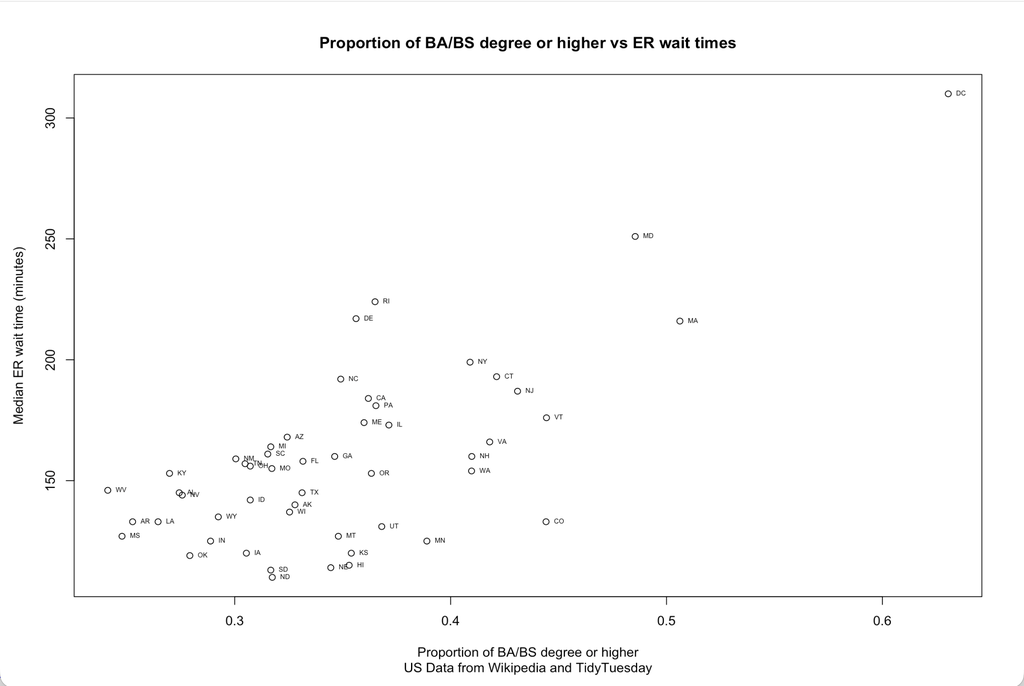

## Colors

- R has 657 built-in colors, (see colors() )many more can be created using other libraries. These are colors R recognizes by name.
- There are 3 basic settings used in base R graphics: col=, fg= and bg=
  - col= is used for the colors of lines, symbols and text
  - fg= specifies the colors of axes and borders
  - bg= specifies the color of the background or fill
- There are several specific settings such as col.main= for the plot title, col.axis = for the axis labels etc.
- You can specify colors by name, by hexadecimal code, and by number.
- You can find color specifications everywhere and generate a version that R can use example: [UCLA Colors](https://brand.ucla.edu/identity/colors)
- You can find [websites](https://color-register.org/) to help you choose specific colors

## Finding Colors

You could look at some colors

```r
# colors() # too many, but it's just a vector so...
colors()[c(1:19, 24)]
```

```
 [1] "white"         "aliceblue"     "antiquewhite"  "antiquewhite1"
 [5] "antiquewhite2" "antiquewhite3" "antiquewhite4" "aquamarine"
 [9] "aquamarine1"   "aquamarine2"   "aquamarine3"   "aquamarine4"
[13] "azure"         "azure1"        "azure2"        "azure3"
[17] "azure4"        "beige"         "bisque"        "black"
```

```r
# rgb color model specification
col2rgb(colors()[c(1:19, 24)])
```

```
      [,1] [,2] [,3] [,4] [,5] [,6] [,7] [,8] [,9] [,10] [,11] [,12] [,13]
red    255  240  250  255  238  205  139  127  127   118   102    69   240
green  255  248  235  239  223  192  131  255  255   238   205   139   255
blue   255  255  215  219  204  176  120  212  212   198   170   116   255
      [,14] [,15] [,16] [,17] [,18] [,19] [,20]
red     240   224   193   131   245   255     0
green   255   238   205   139   245   228     0
blue    255   238   205   139   220   196     0
```

```r
# Associating a name with color - UCLA RGB Brand colors are
# UCLA Blue RGB 39 116 174
# UCLA Gold RGB 255 209 0

UCLAB <- rgb(39/255, 116/255, 174/255) # scale 0-255
UCLAG <- rgb(255/255, 209/255, 0/255)
```

## Applying colors

In plot, the `col=` option will work and it can accept vectors of colors too.

```r
plot(
    Sepal.Width ~ Sepal.Length,
    data = iris,
    main = "An Iris Plot",
    sub = "Sepal Width on Sepal.Length",
    xlab = "Sepal Length",
    ylab = "Sepal Width",
    pch = 19, # change default symbol
    col = c(UCLAB, UCLAG) # use both colors or use Hex "#2774AE", "#FFD100"
  )
```

`pch =` will change the default symbol. Try ?pch at the console prompt to see all of the possibilities.

## Rendered

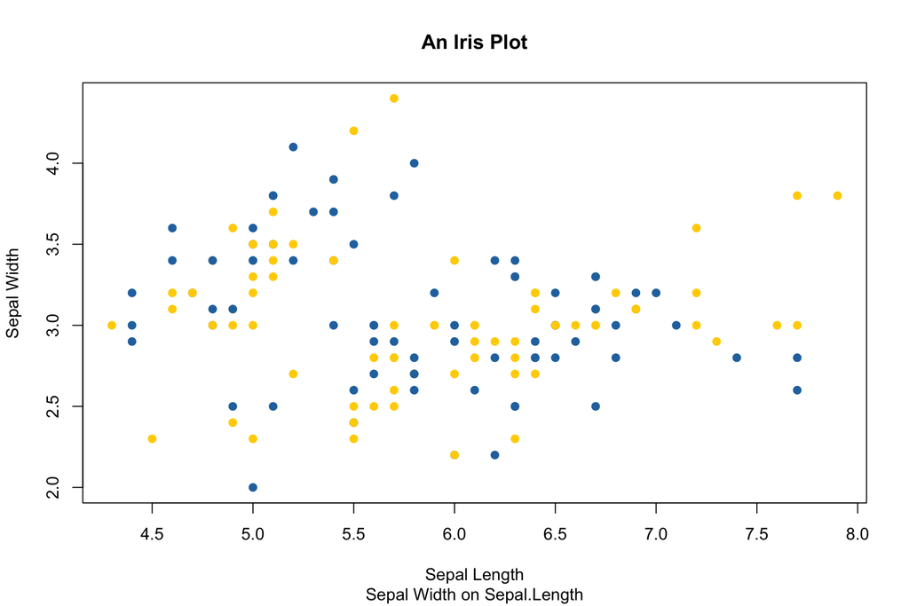

## pch (plotting character)

There are so many, but only some are useful. This matrix displays many of them.

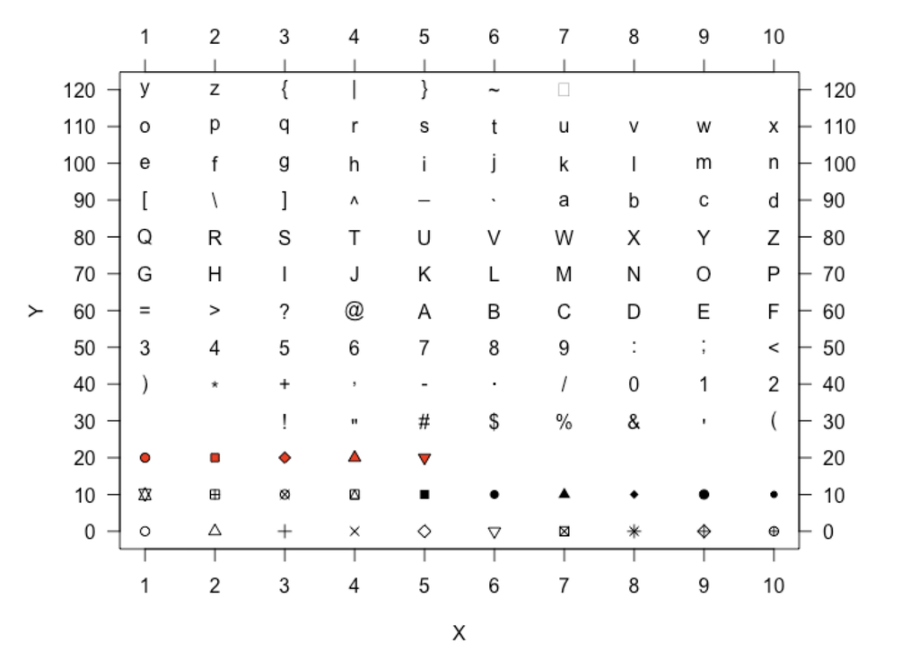

plotting symbol matrix

## cex= (character expansion)

- A quick way to change the size of the points is to use cex=, here we double the size

```r
plot(
    Sepal.Width ~ Sepal.Length,
    data = iris,
    main = "An Iris Plot",
    sub = "Sepal Width on Sepal.Length",
    xlab = "Sepal Length",
    ylab = "Sepal Width",
    pch = 19, # change default symbol
    col = c(UCLAB, UCLAG), # use both colors
    cex = 2 # double default size
  )
```

## rendered

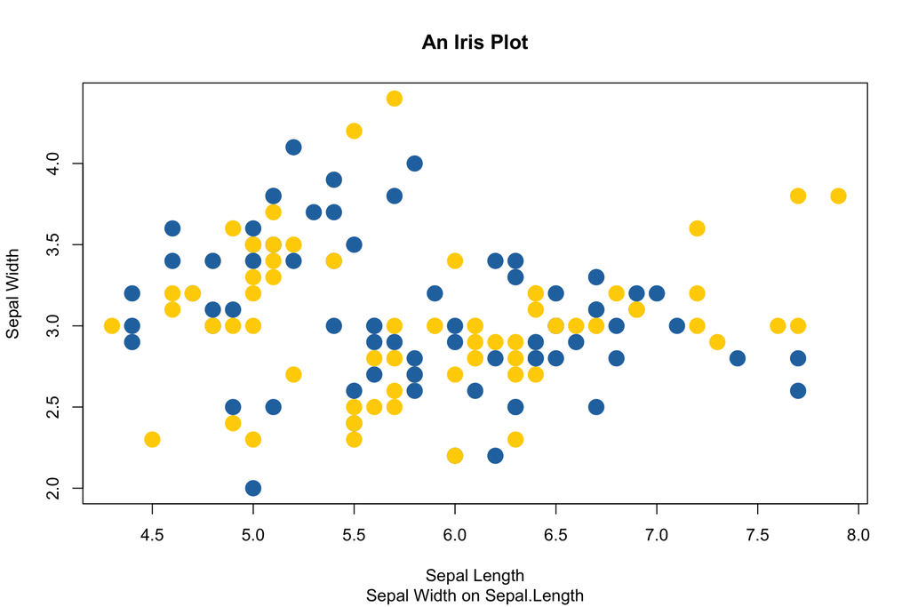

## Adding and modifying lines

- `lwd=` controls the line width, so `lwd= 2` means twice the default thickness
- See ?plot.default for a deeper dive

## Example

- This is a financial data package and we will use it to generate multiple lines to plot.

```r
#install.packages("quantmod")
suppressPackageStartupMessages(library(quantmod))

# Fetch data for the last 90 days
getFX("EUR/USD", from = Sys.Date() - 90) # Sys.Date() is today's date
getFX("GBP/USD", from = Sys.Date() - 90)
getFX("CHF/USD", from = Sys.Date() - 90)
getFX("CAD/USD", from = Sys.Date() - 90)

# Merge them into one dataset for plotting
currency_data <- merge(EURUSD, GBPUSD, CHFUSD, CADUSD)
# head(currency_data) # always check

# multiple lines
plot(x = index(currency_data),  # index values, dates here
     y = currency_data[,1],   # first currency
     ylim = range(currency_data), # makes sure the y-axis is large enough to accommodate the possible values
     type = "l",  # line type - solid
     lwd= 1.5,   # line thickness, 1.5 times default
     main="Currency Trends (Last 2 Months) vs USD",
     col="blue",
     ylab="Exchange Rate")
# we add "low-level" graphical functions, lines()
lines(index(currency_data), currency_data[,2], col="red", lwd= 1.5)
lines(index(currency_data), currency_data[,3], col="green", lwd= 1.5)
lines(index(currency_data), currency_data[,4], col="magenta", lwd= 1.5)
legend("right", legend=c("EUR", "GBP", "CHF", "CAD"),
       col=c("blue", "red", "green", "magenta"), lty= 1, lwd= 1.5, cex= 0.6)
```

## Result

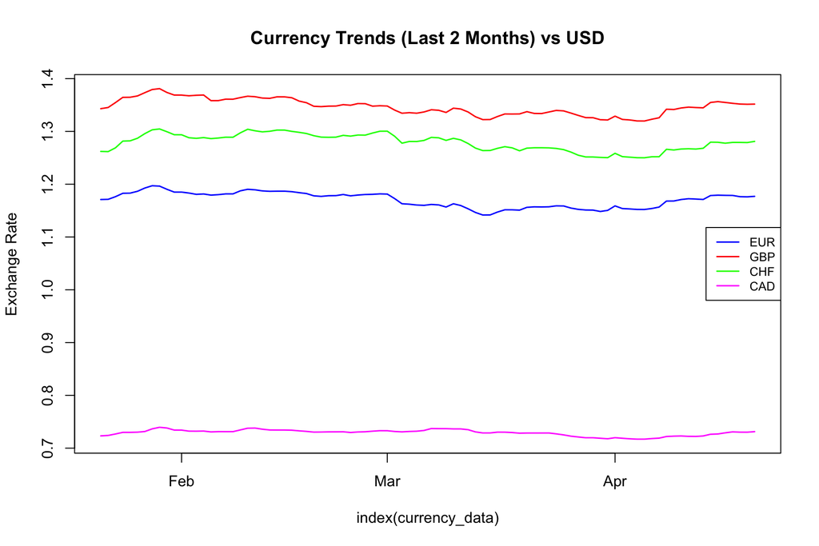

## Notes/suggestions

- Create a blank plot before adding lines OR control the limits (e.g., ylim, xlim)
- Use the `lines()` function to add additional lines
- See ?legend for more assistance, briefly,
  - legend() has position, the most accurate is to give it an x= and y= position
  - but legend can accept:

```
legend("topright", ...)
legend("topleft", ...)
legend("bottomright", ...)
legend("bottomleft", ...)
legend("top", ...)
legend("bottom", ...)
legend("left", ...)
legend("right", ...)
legend("center", ...)
```

## Changing Fonts

- This makes your documents look sharper and will align with company fonts
- Suppose you want to have a “Goldman Sachs” look, download their font.

```
library(systemfonts)
system_fonts() ## reveals the available fonts
fontlist <- system_fonts() |> as.data.frame()  ## if you have very many save them and look
```

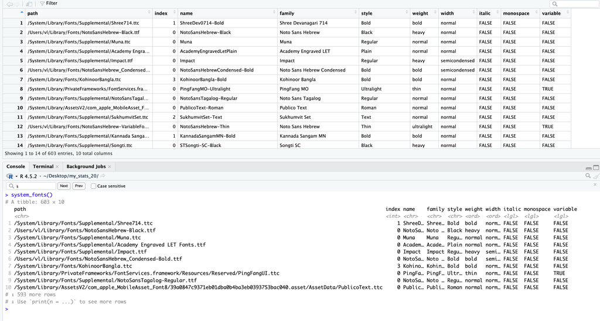

## Complete Example - Iris

```r
plot(Sepal.Width ~ Sepal.Length, data = iris,
                main = "Iris Plot",
                sub = "Sepal Width on Sepal.Length",
                xlab = "Sepal Length",
                ylab = "Sepal Width",
                fg = "blue",
                col = UCLAB,
                col.main = UCLAB,
                col.sub = UCLAG,
                col.lab = UCLAB,
                bg = UCLAG,
                font.axis = 3, # 1: Plain text (Default),
                font.lab = 3, # 3: Italic - if the font has it
                font.main = 2, #  2: Bold - if the font has it
                font.sub = 4, # 4: Bold Italic - if the font has it
                family = "Rockwell", # family = for fonts
                cex = 1.5, # symbols
                cex.main = 2, # title
                cex.axis = 1.1, # axes
                cex.lab = 1.25, # labels
                cex.sub = 0.75, # subtitle
                pch = 21)
```

## Result

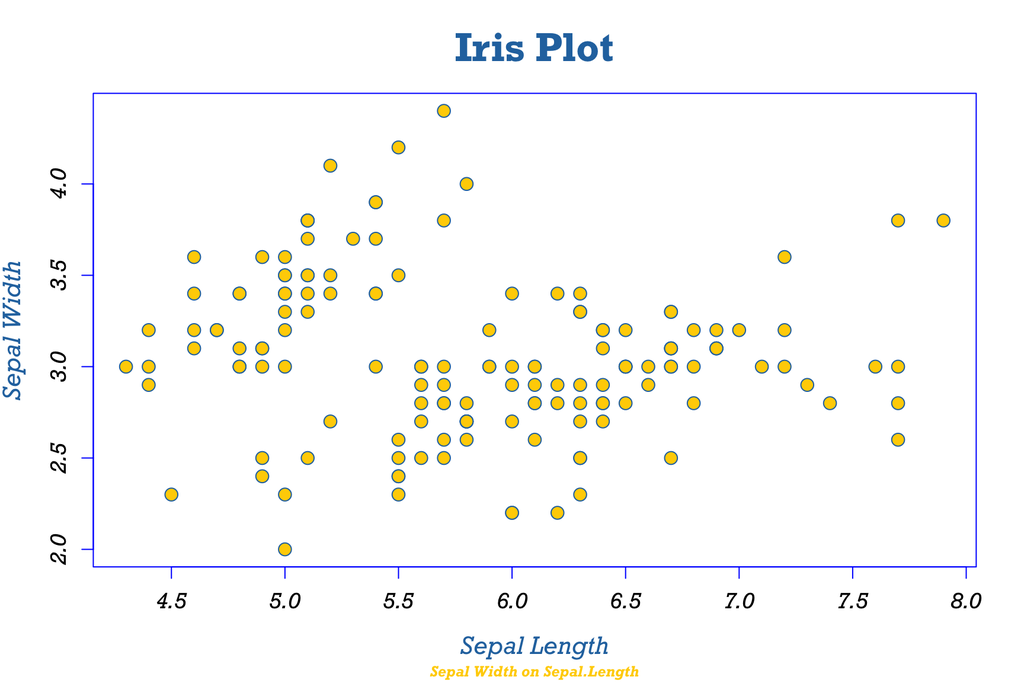

## Another Example

```r
op <- par() # save your current settings
par(family = "Tahoma") # this is a global change until par is restored
# compare with previous example
with(mtcars, plot(wt, mpg, type = "n", ann = FALSE))
points(mtcars$wt[mtcars$gear == 3],
       mtcars$mpg[mtcars$gear == 3],
       pch = 15,
       col = "darkgreen",
       cex = 2) # adds points for gear =3
points(mtcars$wt[mtcars$gear == 4],
       mtcars$mpg[mtcars$gear == 4],
       pch = 18,
       col = "red",
       cex = 2)  # adds points for gear =4
points(mtcars$wt[mtcars$gear == 5],
       mtcars$mpg[mtcars$gear == 5],
       pch = 21,
       bg = "yellow",
       cex = 2) # adds points for gear =5
legend(
  x = min(mtcars$wt), # bottom left
  y = 22.5, # top right
  legend = 3:5,
  col = c("darkgreen", "red", "black"),
  pch = c(15, 18, 21),
  pt.bg = "yellow",
  title = "gear"
) # adds a legend
title(main = "mtcars Example",
      xlab = "weight", ylab = "mpg") # adds titles
text(4,30,"You may add text \n in a different font", family = "AmericanTypewriter-Bold")
par(op)
```

## Result

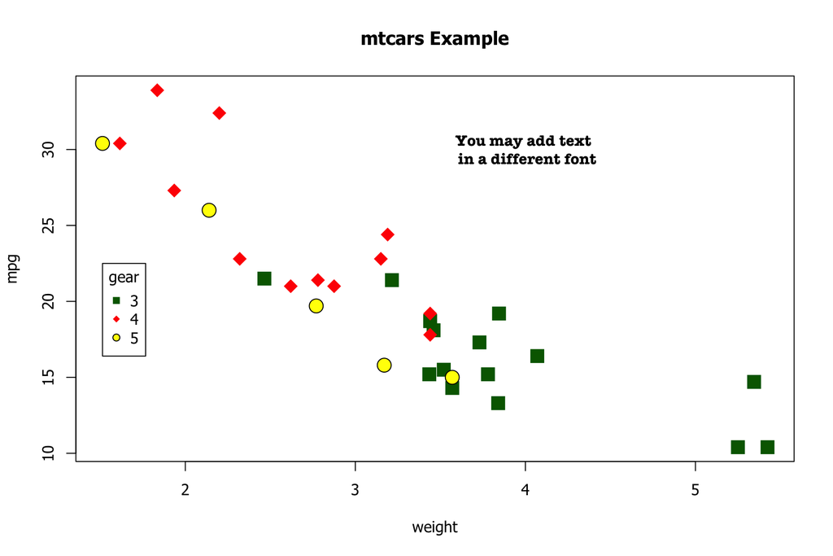

## A Problem

- Scatter plot is fine when we have homework style data
- But what happens when it gets big?

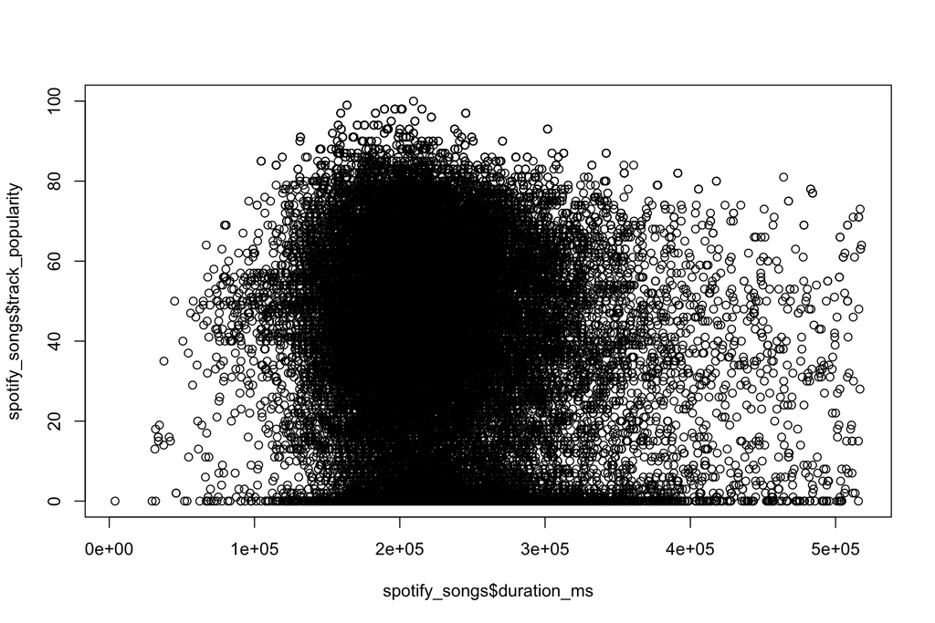

```r
load("spotify_songs.RData")
plot(x = spotify_songs$duration_ms, y = spotify_songs$track_popularity)
```

# FILTERING

## filtering in base R

- An important skill and when we examine the Tidyverse, you can judge
- Let’s suppose we think ‘we will drop the least popular’
- In base R filtering means:

> Keep **rows** where a condition is TRUE.

Everything comes back to this fundamental pattern:

```
df[ some_condition , ]
```

- read “we have a dataframe (df) extract some_condition is TRUE all the columns”

## Application

- Suppose we want to keep those tracks which have a popularity of at least 1 because we noticed about 10% of songs had a popularity of zero.
- Our condition translated into R, looks like

```
spotify_songs$track_popularity >= 1
```

or

```
spotify_songs$track_popularity > 0
```

- Unfortunately, if you only ran this, R would return a vector with as many rows as spotify_songs but full of TRUE and FALSE (try it, you’ll see)
- BUT when we insert it into a dataframe extract:

```
spotify_songs[spotify_songs$track_popularity >= 1, ]
```

- R will respond by keeping only those rows for which this condition is true and give us the filtered data frame that we want to use.

## Make it real

```r
# our conditioning variable
fivenum(spotify_songs$track_popularity)
```

```
[1]   0  24  45  62 100
```

```r
# filter with a condition
spotify_filtered <- spotify_songs[spotify_songs$track_popularity >= 1, ]

# always check
fivenum(spotify_filtered$track_popularity)
```

```
[1]   1  31  48  63 100
```

- Now plot it

```r
plot(x = spotify_filtered$duration_ms, y = spotify_filtered$track_popularity,
     main = "Filtered and possibly more useless than ever")
```

## Result

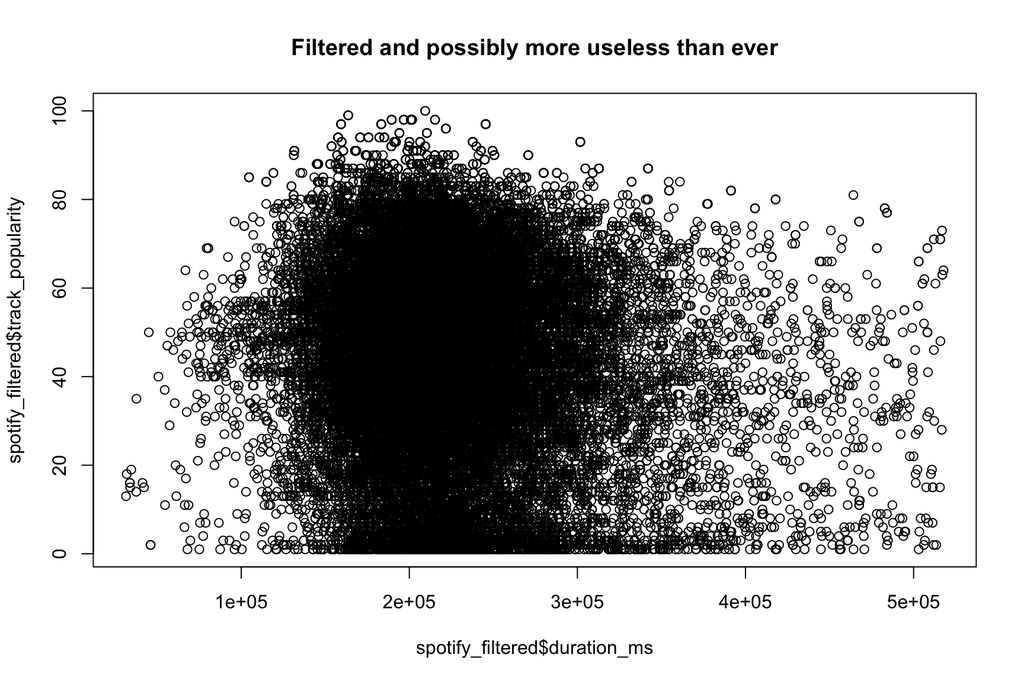

## smoothScatter

- `smoothScatter()` turns a scatterplot into a color map that shows where points are most concentrated
- This is useful when you have so many data points, it is difficult to see anything useful in your scatterplot.

```r
rgb.palette <- colorRampPalette(c("blue", "orange", "red"), space = "rgb")
smoothScatter(x = spotify_filtered$duration_ms,
              y = spotify_filtered$track_popularity,
              colramp = rgb.palette,
              main = "But patterns may begin to emerge")
```

## smoothScatter Result

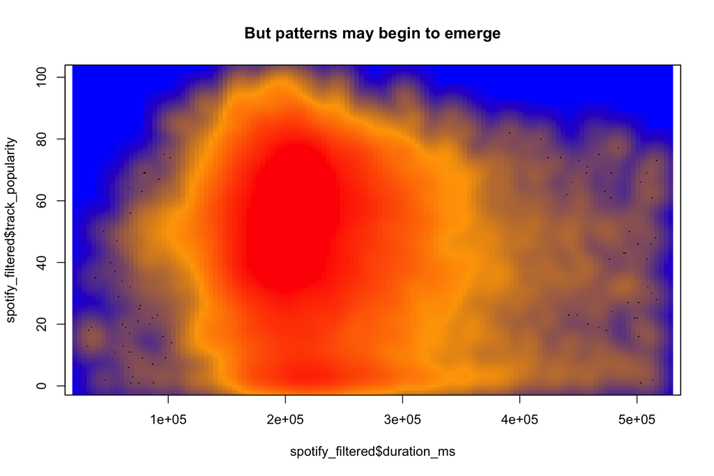

# Breathe/Questions

# Good to Know

## Resizing

- At the start of a Quarto chunk, you can insert all kinds of modifications:

```
#| echo: false
#| warning: false
#| fig-width: 10
#| fig-height: 8
#| fig-cap: "A nice image."
```

- At the start of an RMarkdown chunk, insert something like

```
{r echo=FALSE, out.width="50%", fig.cap="A nice image."}
```

- echo=FALSE - hide the R, out.width=“50%” - half the width the default, fig.cap = a caption

## Saving images with no extras

- There are other ways to write images, this is without any additional libaries

```r
# Open the device
png("base_plot.png", width = 800, height = 600, res = 100)

# run R
plot(mtcars$wt, mtcars$mpg, main = "Base R Plot")

# CLOSE the device (CRITICAL: this actually saves the file)
dev.off()
```

# Base R Graphics

## Quick Survey

- While `plot()` can do many things, you should have some knowledge of other functions if you were limited to using base R and no access additional libraries.
- barplot
- mosaicplot
- boxplot
- heatmap
- hist
- pairs
- persp
- contour

# Barplot

## Rectangles are the clearest

```r
help(barplot)
```

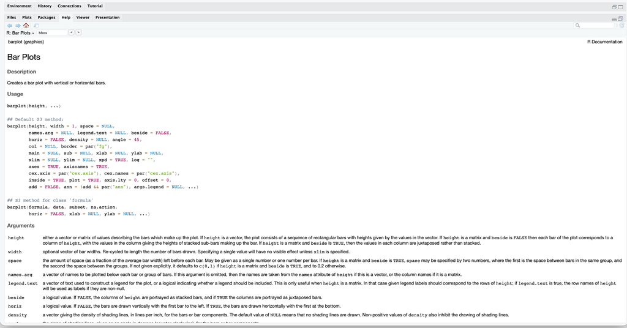

barplot_help

## Barplot is “not smart”

- barplot() will not do math for you, so your data must be in totals (or tabled)
- if it is a vector (one-way table), each value will be a bar
- if it is a matrix (two-way table), each column will be bar

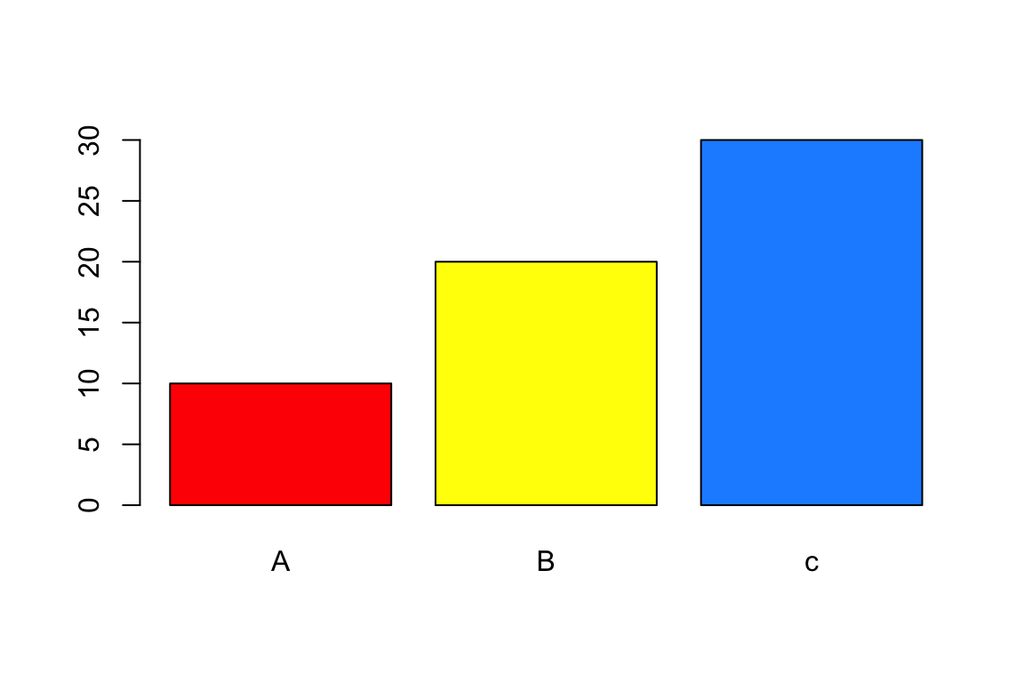

```r
# Each value gets a bar and a color
my_vector <- c(A = 10, B = 20, c = 30)
barplot(my_vector, col = c("red", "yellow", "dodgerblue"))
```

## Matrix example

- The assumption is that the numerical values are some type of total or count value
- Matrices need to be convert to a two-way table to be plotted here

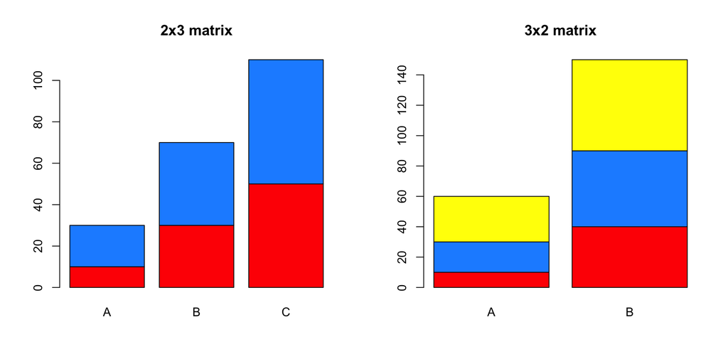

```r
op <- par() # store the defaults, turn your warnings off
par(mfrow = c(1,2)) # change the plot window appearance
matrix(seq(10, 60, by= 10), nrow = 2) |> as.table() |> barplot(col = c("red", "dodgerblue"), main = "2x3 matrix")
matrix(seq(10, 60, by= 10), nrow = 3) |> as.table() |> barplot(col = c("red", "dodgerblue", "yellow"), main = "3x2 matrix")
```

```r
par(op) # restore the original
```

## Aside: table()

- The table() function is ancient but easy and useful. Especially when trying to build data for plots
- from the documentation, simplified

```
table(...,
      exclude = if (useNA == "no") c(NA, NaN),
      useNA = c("no", "ifany", "always"),
      dnn = list.names(...), deparse.level = 1)

...        one or more objects which can be interpreted as factors (including numbers or character strings), or a list (such as a data frame) whose components can be so interpreted.
exclude  levels to remove for all factors in .... If it does not contain NA and useNA is not specified, it implies useNA = "ifany".
```

- it needs to be demo’ed, then you are quite clever and can build on the basics
- I would recommend always setting `useNA = "always"` until you know there are no NA in your data or have dealt with them.

## table() introduction

- Let’s use, “pokemon.RData”, which contained one data frame called `pokemon_df`
- A mix of numeric and non-numeric data, how to work with the non-numeric?
- Look for variables with only a few unique values to get a distribution of counts which could be converted to proportions

```r
load("pokemon.RData")
ls()
```

```
 [1] "CADUSD"           "CHFUSD"           "currency_data"    "EURUSD"
 [5] "GBPUSD"           "my_vector"        "op"               "pokemon_df"
 [9] "rgb.palette"      "spotify_filtered" "spotify_songs"    "UCLAB"
[13] "UCLAG"
```

```r
names(pokemon_df)
```

```
 [1] "id"              "pokemon"         "species_id"      "height"
 [5] "weight"          "base_experience" "type_1"          "type_2"
 [9] "hp"              "attack"          "defense"         "special_attack"
[13] "special_defense" "speed"           "color_1"         "color_2"
[17] "color_f"         "egg_group_1"     "egg_group_2"     "url_icon"
[21] "generation_id"   "url_image"
```

```r
unique(pokemon_df$egg_group_1) # unique answers "how many unique values" aslo pokemon_df[["egg_group_1"]]
```

```
 [1] "monster"       "bug"           "flying"        "ground"
 [5] "no-eggs"       "fairy"         "plant"         "water1"
 [9] "humanshape"    "water3"        "mineral"       "indeterminate"
[13] "water2"        "ditto"         "dragon"
```

```r
unique(pokemon_df$generation_id) # this is numeric, but limited values
```

```
[1]  1  2  3  4  5  6  7 NA
```

## table useNA = “always”

- Because data is almost never perfect

```r
table(pokemon_df$generation_id)
```

```
  1   2   3   4   5   6   7
151 100 135 107 156  72  81
```

- BUT

```r
table(pokemon_df$generation_id, useNA= "always")
```

```
   1    2    3    4    5    6    7 <NA>
 151  100  135  107  156   72   81  147
```

- You might have the wrong impression if you don’t account for missingness,

```r
(table(pokemon_df$generation_id)  |> prop.table()) |> round(digits = 2)
```

```
   1    2    3    4    5    6    7
0.19 0.12 0.17 0.13 0.19 0.09 0.10
```

```r
(table(pokemon_df$generation_id, useNA= "always") |> prop.table()) |> round(digits = 2)
```

```
   1    2    3    4    5    6    7 <NA>
0.16 0.11 0.14 0.11 0.16 0.08 0.09 0.15
```

# Mosaicplot

## Mosaicplot (for tables)

- These display the relationship between two or more non-numeric variables

```r
mosaicplot(table(pokemon_df$generation_id, pokemon_df$type_1,
               useNA= "always"),
               main = "Pokemon Type by Generation",
               las=1, # labels always horizontal
               col = c("#A8B820", "#F08030", "#6890F0", "#78C850", "#F8D030",
               "#FA8072", "#E0C068", "#EE99AC", "#C03028", "#A040A0",
               "#A8A878", "#B8A038", "#705898", "#98D8D8", "#7038F8",
               "#B8B8D0", "#D89090"))
```

## Mosaicplot result

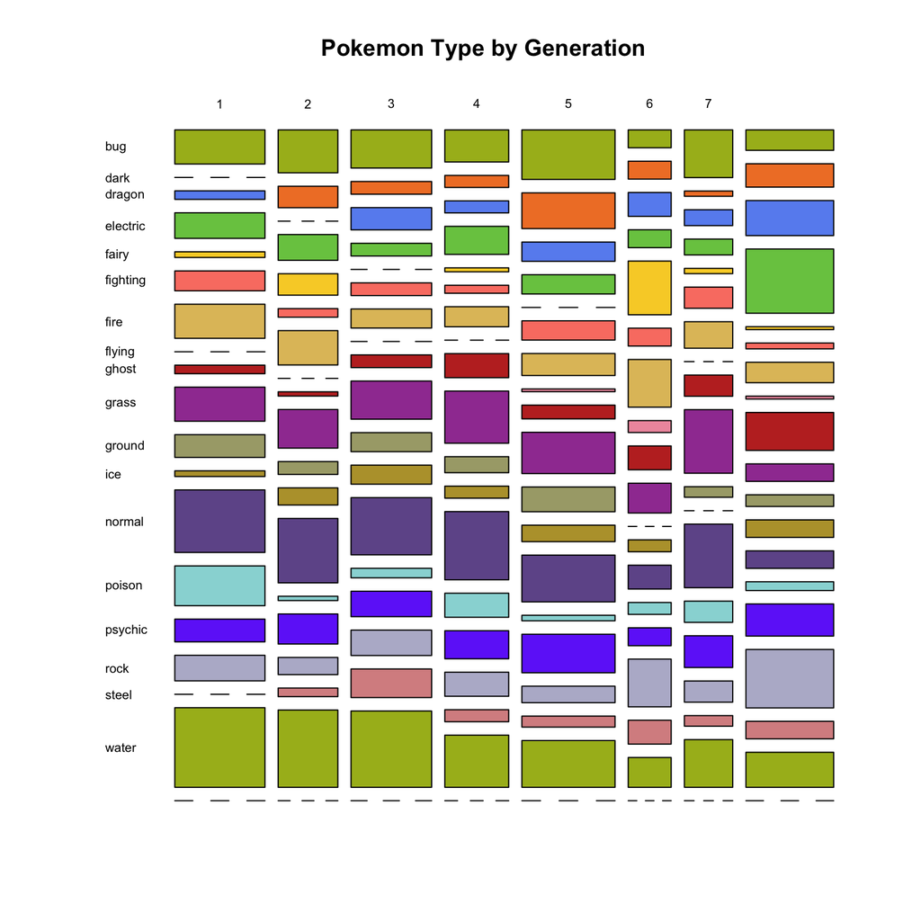

# Boxplot

## Boxplot

- Best application - 2 variables - one numeric, one categorical (grouping)

```
Usage
boxplot(x, ...)

## S3 method for class 'formula'
boxplot(formula, data = NULL, ..., subset, na.action = NULL,
        xlab = mklab(y_var = horizontal),
        ylab = mklab(y_var =!horizontal),
        add = FALSE, ann = !add, horizontal = FALSE,
        drop = FALSE, sep = ".", lex.order = FALSE)

## Default S3 method:
boxplot(x, ..., range = 1.5, width = NULL, varwidth = FALSE,
        notch = FALSE, outline = TRUE, names, plot = TRUE,
        border = par("fg"), col = "lightgray", log = "",
        pars = list(boxwex = 0.8, staplewex = 0.5, outwex = 0.5),
         ann = !add, horizontal = FALSE, add = FALSE, at = NULL)
```

## Boxplot (cont’d)

- Recommend the formula method because it is cleaner looking
- But the older style works just fine, whatever is easiest for you

```r
boxplot(defense ~ type_1,
        data = pokemon_df,
        main = "Boxplot of defense by first type",
        xlab = "first type",
        ylab = "points",
        col = c("#A8B820", "#F08030", "#6890F0", "#78C850", "#F8D030", "#FA8072", "#E0C068", "#EE99AC", "#C03028", "#A040A0",
        "#A8A878", "#B8A038", "#705898", "#98D8D8", "#7038F8", "#B8B8D0", "#D89090")
        )
```

- note the colors are extracted from the data, and are in “hex” (see [Google Color Picker](https://share.google/Xb93LQWAlCYzKd0yv))
- note the problem with the x-axis we have so many categories (next slide)

## Result

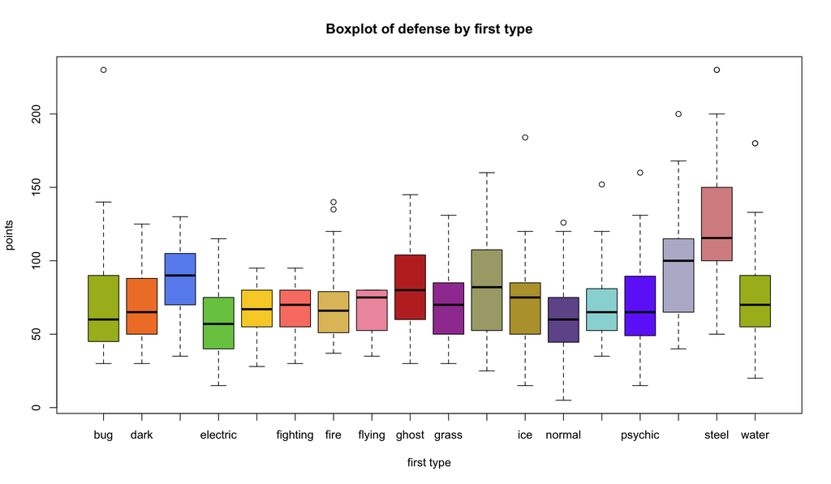

## Aside - cex.axis=

- Shrink the x-axis labels using graphical options from plot()

```r
boxplot(defense ~ type_1, data = pokemon_df,
        main = "Boxplot of defense by first type", xlab = "first type", ylab = "points",
        col = c("#A8B820", "#F08030", "#6890F0", "#78C850", "#F8D030",
                "#FA8072", "#E0C068", "#EE99AC", "#C03028", "#A040A0",
                "#A8A878", "#B8A038", "#705898", "#98D8D8", "#7038F8", "#B8B8D0", "#D89090"),
        cex.axis = 0.85
        )
```

## Result - cex.axis=

- Shrink the x-axis labels using graphical options from plot()

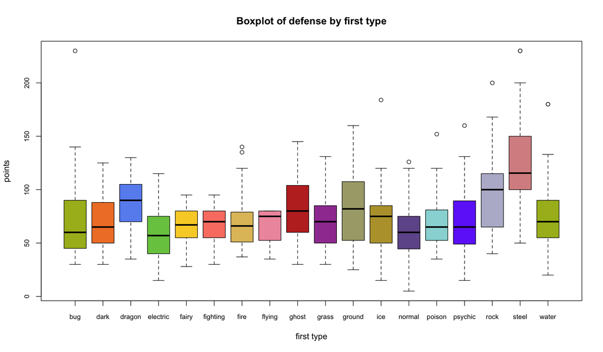

# Heatmap

## Heatmap

- We can draw better and more flexible heatmaps using other packages but base R has one and if you haven’t seen one before, here is your introduction.

```r
x  <- as.matrix(pokemon_df[c(6, 150, 130, 131, 132, 133, 1, 143, 4, 94, 59, 38, 65, 25, 26), c(4:6, 9:14)])
row.names(x) <- pokemon_df$pokemon[c(6, 150, 130, 131, 132, 133, 1, 143, 4, 94, 59, 38, 65, 25, 26)]
heatmap(x, Colv = NA, Rowv = NA, col = hcl.colors(256), scale = "column",
        xlab = "", ylab =  "",
        main = "Heatmap of some Pokemon and their Abilities", cexCol = 0.7)
```

## Heatmap result

[figure not shown]

## Takeaway for the Heatmap

- A heat map is a just tool like the others tools
- It is a scaled matrix of numerical values represented by colors
- They represent Z-scores (standard deviations from the mean of the column)
- A “Hot” color (here, Yellow): This value is high relative to other values.
- A “Cold” color (here deep Purple): This value is low relative to the other.

# Histogram

## Histogram Characteristics

- Designed for Continuous Data – esp. data measured on a scale, such as height, weight, age etc.
- Histograms generally have no gaps between bars (compare boxplot)
- Used to identify the shape of data (e.g., symmetry or skewness), central tendency, and spread.
- Can be used for outlier detection - gaps or unusual data points

## hist() for histograms

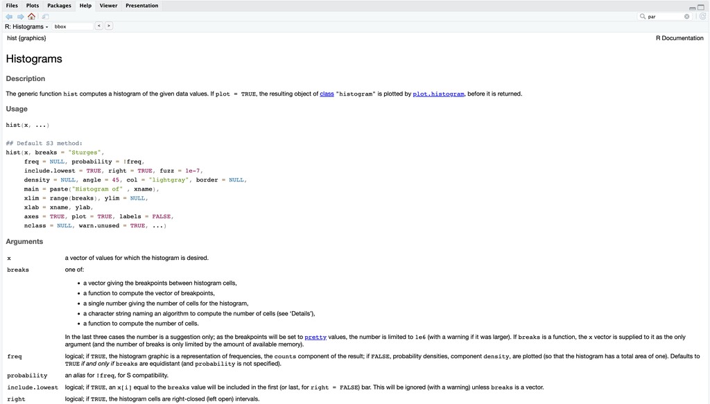

help(hist)

## basic example

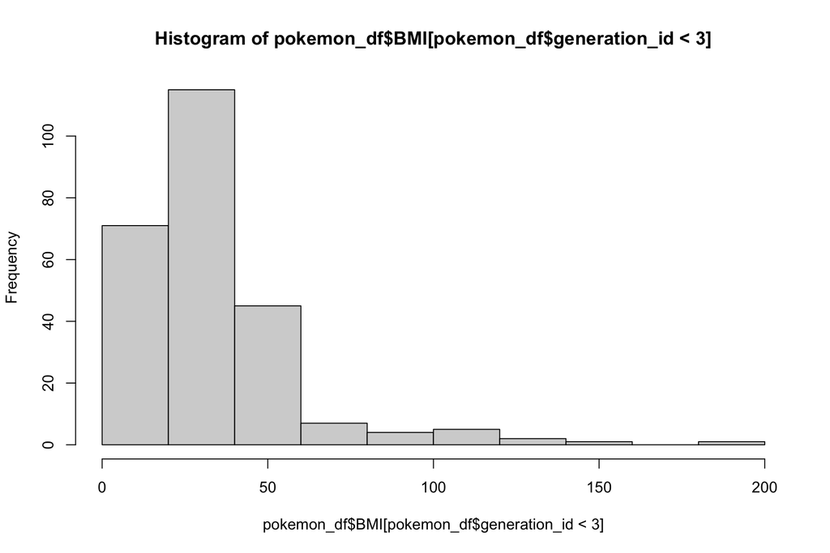

```r
pokemon_df$BMI <- pokemon_df$weight / (pokemon_df$height)^2
hist(pokemon_df$BMI[pokemon_df$generation_id < 3])
```

## common options

- add titles and labels, change color, change to density

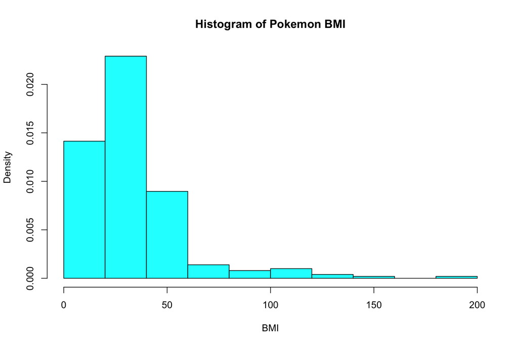

```r
hist(pokemon_df$BMI[pokemon_df$generation_id < 3], prob = TRUE, col = "cyan",
     xlab = "BMI", main = "Histogram of Pokemon BMI")
```

## additional options

- adjust the number of breaks (cells), adjust the height of the y-axis, add lines and legend

```r
hist(pokemon_df$BMI[pokemon_df$generation_id < 3], prob = TRUE, col = "cyan",
     xlab = "BMI", main = "Histogram of Pokemon BMI", breaks = 20, ylim = c(0, 0.03))
# Add density curve
density_curve <- density(pokemon_df$BMI[pokemon_df$generation_id < 3],
                       na.rm = TRUE) # Remove NA values if any
lines(density_curve, col = "red", lwd = 2) # Add density to plot

# Calculate median BMI for each generation
median_bmi01 <- median(pokemon_df$BMI[pokemon_df$generation_id == 1],
     na.rm = TRUE)
median_bmi02 <- median(pokemon_df$BMI[pokemon_df$generation_id == 2],
     na.rm = TRUE)

# Add vertical line for median BMIs for gen1 and gen2
abline(v = median_bmi01, col = "blue", lwd = 2, lty = 2)
# Add vertical line with blue color, width 2, and dashed line type
abline(v = median_bmi02, col = "magenta", lwd = 2, lty = 2)
# Add vertical line with magenta color, width 2, and dashed line type

# Add legend with location, text, specified colors and line types
legend("topright",
       legend = c("Density Curve", "Median BMI Gen 1", "Median BMI Gen 2"),
       col = c("red", "blue", "magenta"), lwd = 2, lty = c(1, 2, 2))
```

## result

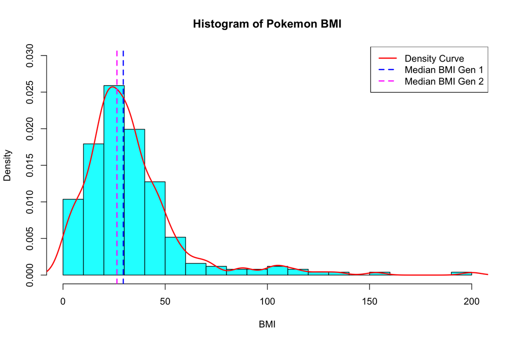

# And others

## image, persp, contour

- image() displays data as a image, contour() as lines of equal height, and persp() as a 3D surface. All using the same data in a panel display

```r
# Save current graphical settings
op <- par()

# Layout: 1 row, 3 columns
par(mfrow = c(1, 3), mar = c(4, 4, 3, 2), oma = c(0, 0, 2, 0))

# Image (heatmap-style)
image(
  volcano,
  col = terrain.colors(20),
  main = "image(volcano)",
  xlab = "X",
  ylab = "Y"
)

# Contour
contour(
  volcano,
  col = "darkgreen",
  lwd = 1.2,
  main = "contour(volcano)",
  xlab = "X",
  ylab = "Y"
)

# Perspective (3D)
persp(
  volcano,
  theta = 40,
  phi = 20,
  expand = 0.6,
  col = "tan",
  shade = 0.5,
  border = "gray",
  main = "persp(volcano)"
)

# Overall title
mtext("Three Views of the Same Data (volcano matrix)", outer = TRUE)

# Restore settings
par(op)
```

## Result

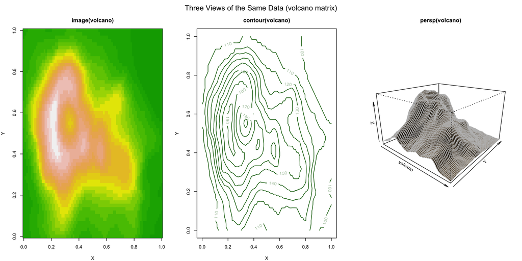

## Takeaways

- These are just tools
- There are so many graphical functions and options for them that it is a bit overwhelming.
- What will help is to have a clear idea of the message or story that you wish to tell
- That helps you decide which data visualization is most suitable for your needs
- Next time, we will look at a “grammatical” approach to data visualization.